# Project1

Anchal Saxena

6/8/2019

# Intro to XML

Describe your type of data (JSON or XML). What is it, where does it get used, and why is it a good way to store data? XML stands for *Extensible Markup Language*.

XML is used to **describe data** and to focus on **what data is**. In XML user can use custom definition, description and structure of data. These datasets then can be stored and shared in the user format across internet and other networks.

## Benefits

Important characteristics of XML that make it useful in a variety of systems and solutions −

1. XML is extensible − XML allows you to create your own self-descriptive tags, or language, that suits your application.
2. XML carries the data, does not present it − XML allows you to store the data irrespective of how it will be presented.
3. XML is a public standard − XML was developed by an organization called the World Wide Web Consortium (W3C) and is available as an open standard.

For more informstion, visit [this website](https://www.tutorialspoint.com/xml/xml_overview.htm)!

## Description of Data

**NCHS - Leading Causes of Death: United States**, census dataset from the National Center for Health Statistics presents age-adjusted death rates for the 10 leading causes of death in the US beginning in 1999. Age-adjusted death rates are (per 100,000 population) based on the 2000 US standard population.

To get detailed information,click [here](https://catalog.data.gov/dataset/age-adjusted-death-rates-for-the-top-10-leading-causes-of-death-united-states-2013).

# Read Data

To begin reading in XML data, follow these steps:

1. Load in the XML package
2. Use xmlParse(“Path to file”) to read in your XML file.
3. Use xmlToDataframe to create a dataframe for each node in the xml data.

```r
library(XML)
library(DT)
library(dplyr)
library(methods)
library(tidyverse)
#The xmlParse() comes from the XML package in R.
#This is used commonly to parse or analyze each component of an XML file.
#This helps to generate an R structure representing the XML tree.
xmlData <- xmlParse("http://data.cdc.gov/api/views/bi63-dtpu/rows.xml")
#extract xml data to dtatframe
year <- setNames(xmlToDataFrame(node=getNodeSet(xmlData, "//year")), "Year")
cause <- setNames(xmlToDataFrame(node=getNodeSet(xmlData, "//cause_name")), "Cause")
deaths <- setNames(xmlToDataFrame(node=getNodeSet(xmlData, "//deaths")), "Deaths")
state <- setNames(xmlToDataFrame(node=getNodeSet(xmlData, "//state")), "State")
aadr <- setNames(xmlToDataFrame(node=getNodeSet(xmlData, "//aadr")), "AADR")
xmlDataDf <- cbind(year, cause, deaths, state, aadr)
str(xmlDataDf)
```

```
## 'data.frame':    10296 obs. of  5 variables:
##  $ Year  : Factor w/ 18 levels "1999","2000",..: 14 18 15 2 16 11 13 17 16 15 ...
##  $ Cause : Factor w/ 11 levels "All causes","Alzheimer's disease",..: 8 8 8 10 8 10 8 8 8 8 ...
##  $ Deaths: Factor w/ 5741 levels "100","100056",..: 1886 2829 2829 2058 3046 2716 4030 3478 3347 3378 ...
##  $ State : Factor w/ 52 levels "Alabama","Alaska",..: 47 47 47 9 3 9 42 47 47 3 ...
##  $ AADR  : Factor w/ 2457 levels "10","10.0","10.1",..: 709 1178 1179 1179 1306 1307 1308 1308 1308 1309 ...
```

```r
options(digits = 10)
#Convert AADR, Deaths & Year to numeric variables
xmlDataDf$AADR <- as.numeric(xmlDataDf$AADR)
xmlDataDf$Deaths <- as.numeric(xmlDataDf$Deaths)

str(xmlDataDf)
```

```
## 'data.frame':    10296 obs. of  5 variables:
##  $ Year  : Factor w/ 18 levels "1999","2000",..: 14 18 15 2 16 11 13 17 16 15 ...
##  $ Cause : Factor w/ 11 levels "All causes","Alzheimer's disease",..: 8 8 8 10 8 10 8 8 8 8 ...
##  $ Deaths: num  1886 2829 2829 2058 3046 ...
##  $ State : Factor w/ 52 levels "Alabama","Alaska",..: 47 47 47 9 3 9 42 47 47 3 ...
##  $ AADR  : num  709 1178 1179 1179 1306 ...
```

# Data Analysis

[output not shown]

# Visual Summary - Quantitave

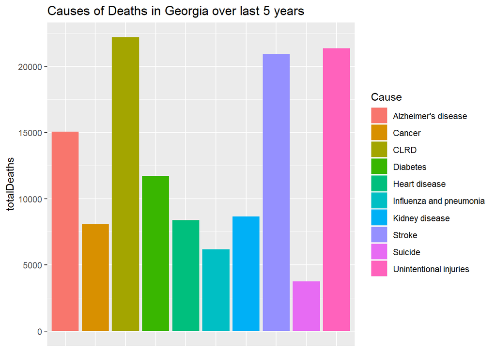

[figure not shown]